# 楊子萱_110700049_hw09

楊子萱

2023-12-02

# Introduction

In order to conduct the clustering models, I have chosen the dataset “Sleep_health_and_lifestyle_dataset”. The models I will be using are listed below.

# Clustering Models

1. Hierarchical Clustering

```
a. Agglomerative Hierarchical Method

  i. Single Linkage

  ii. Complete Linkage

  iii. Average Linkage

b. Divisive Hierarchical Method

  i. Complete Linkage

c. Ward's Method
```

2. K-Means Clustering

```
a. K determined by the Elbow Method

a. K determined by the Silhouette Method
```

# Importing Libraries

```r
library(ggplot2)
library(dplyr)
library(nnet)
library(irr)
library(Metrics)
library(pROC)
library(e1071)
library(cluster)
library(tidyr)
library(mclust)
library(caret)
```

# Read Data

```r
data = read.csv(file = 'Sleep_health_and_lifestyle_dataset.csv', header = TRUE, sep = ',')
```

## b. Check Type & Structure of Data

```r
class(data)
```

```
## [1] "data.frame"
```

```r
str(data)
```

```
## 'data.frame':    374 obs. of  13 variables:
##  $ Person.ID              : int  1 2 3 4 5 6 7 8 9 10 ...
##  $ Gender                 : chr  "Male" "Male" "Male" "Male" ...
##  $ Age                    : int  27 28 28 28 28 28 29 29 29 29 ...
##  $ Occupation             : chr  "Software Engineer" "Doctor" "Doctor" "Sales Representative" ...
##  $ Sleep.Duration         : num  6.1 6.2 6.2 5.9 5.9 5.9 6.3 7.8 7.8 7.8 ...
##  $ Quality.of.Sleep       : int  6 6 6 4 4 4 6 7 7 7 ...
##  $ Physical.Activity.Level: int  42 60 60 30 30 30 40 75 75 75 ...
##  $ Stress.Level           : int  6 8 8 8 8 8 7 6 6 6 ...
##  $ BMI.Category           : chr  "Overweight" "Normal" "Normal" "Obese" ...
##  $ Blood.Pressure         : chr  "126/83" "125/80" "125/80" "140/90" ...
##  $ Heart.Rate             : int  77 75 75 85 85 85 82 70 70 70 ...
##  $ Daily.Steps            : int  4200 10000 10000 3000 3000 3000 3500 8000 8000 8000 ...
##  $ Sleep.Disorder         : chr  "None" "None" "None" "Sleep Apnea" ...
```

# 1. Hierarchical Clustering

## a. Agglomerative Hierarchical Method

### i. Single Linkage

```r
distances <- dist(data)
hclust_result <- hclust(distances, method = "single")

num_clusters <- 3

clusters <- cutree(hclust_result, num_clusters)
silhouette_score <- silhouette(clusters, distances)
cluster_counts <- table(clusters)
true_labels <- data$Quality.of.Sleep
cluster_table <- table(clusters, true_labels)
purity <- sum(apply(cluster_table, 2, max)) / sum(cluster_table)

cat("Silhouette Score:", mean(silhouette_score[, "sil_width"]), "\n")
```

```
## Silhouette Score: 0.7012141
```

```r
cat("Purity:", purity, "\n")
```

```
## Purity: 0.6925134
```

```r
cat("\nNumber of Observations For Each Combination of Cluster Assignment:\n")
```

```
##
## Number of Observations For Each Combination of Cluster Assignment:
```

```r
print(cluster_table)
```

```
##         true_labels
## clusters   4   5   6   7   8   9
##        1   5   7  64  45   7  36
##        2   0   0  34   0   0   2
##        3   0   0   7  32 102  33
```

```r
cat("\nNumber of Observations in Each Cluster:\n")
```

```
##
## Number of Observations in Each Cluster:
```

```r
print(cluster_counts)
```

```
## clusters
##   1   2   3
## 164  36 174
```

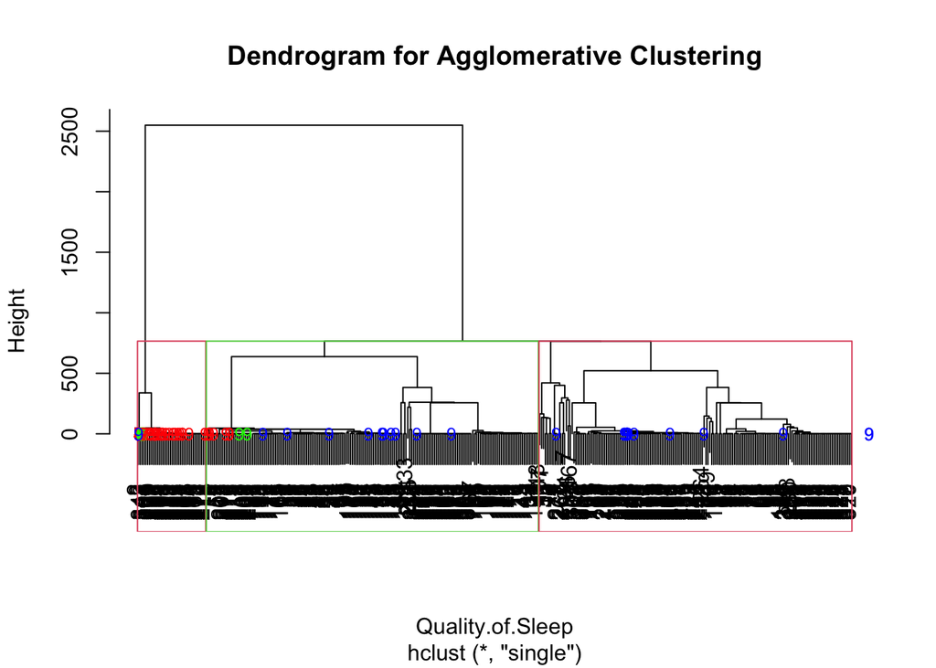

```r
plot(hclust_result, main = "Dendrogram for Agglomerative Clustering", xlab = "Quality.of.Sleep", sub = NULL)

rect.hclust(hclust_result, k = num_clusters, border = 2:num_clusters)

labels <- as.character(data$Quality.of.Sleep)
labels[labels == "Nine"] <- "9"
labels[labels == "Eight"] <- "8"
labels[labels == "Seven"] <- "7"
labels[labels == "Six"] <- "6"
labels[labels == "Five"] <- "5"
labels[labels == "Four"] <- "4"

label_colors <- rainbow(num_clusters)[clusters]

text(x = hclust_result$height, y = 0, labels = labels, col = label_colors, cex = 0.8)
```

The agglomerative clustering algorithm with single linkage starts with each data point as a single cluster, and then merges the two clusters with the smallest single-linkage distance until all data points belong to a single cluster. In single linkage, the distance between two clusters is defined as the shortest distance between any two points in the two clusters. The Silhouette Score is a measure of how similar an object is to its own cluster compared to other clusters. In order to have a nice balance between the silhouette score and the purity, I have set the number of clusters to 3. From the results, we can see that this algorithm achieves a **high** silhouette score, indicating that there’re **well-defined clusters**. Besides, the purity is relatively **high**, meaning that on average, the clusters have a **good alignment** with true classes. Overall, the agglomerative clustering algorithm with single linkage seems to have identified **meaningful patterns** in the data.

### ii. Complete Linkage

```r
hclust_result <- hclust(distances, method = "complete")

num_clusters <- 4

clusters <- cutree(hclust_result, num_clusters)
silhouette_score <- silhouette(clusters, distances)
cluster_counts <- table(clusters)
true_labels <- data$Quality.of.Sleep
cluster_table <- table(clusters, true_labels)
purity <- sum(apply(cluster_table, 2, max)) / sum(cluster_table)

cat("Silhouette Score:", mean(silhouette_score[, "sil_width"]), "\n")
```

```
## Silhouette Score: 0.68779
```

```r
cat("Purity:", purity, "\n")
```

```
## Purity: 0.657754
```

```r
cat("\nNumber of Observations For Each Combination of Cluster Assignment:\n")
```

```
##
## Number of Observations For Each Combination of Cluster Assignment:
```

```r
print(cluster_table)
```

```
##         true_labels
## clusters   4   5   6   7   8   9
##        1   3   5   3   4   0   2
##        2   0   0  34   0   0   2
##        3   0   0   7  32 102  33
##        4   2   2  61  41   7  34
```

```r
cat("\nNumber of Observations in Each Cluster:\n")
```

```
##
## Number of Observations in Each Cluster:
```

```r
print(cluster_counts)
```

```
## clusters
##   1   2   3   4
##  17  36 174 147
```

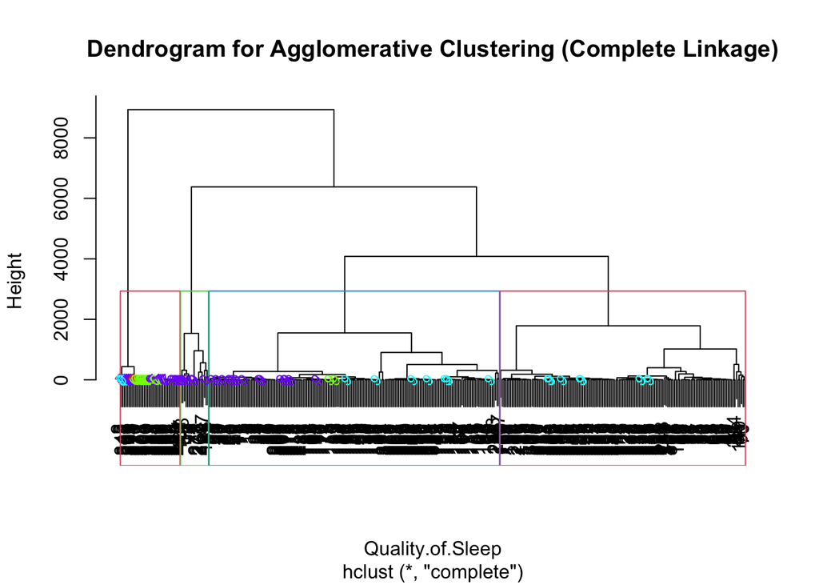

```r
plot(hclust_result, main = "Dendrogram for Agglomerative Clustering (Complete Linkage)", xlab = "Quality.of.Sleep", sub = NULL)

rect.hclust(hclust_result, k = num_clusters, border = 2:num_clusters)

label_colors <- rainbow(num_clusters)[clusters]

text(x = hclust_result$height, y = 0, labels = labels, col = label_colors, cex = 0.8, srt = 45)
```